# ROV fish densities

Fiona Francis

3/17/2021

# Preliminary analysis of fish and substrate data from 2018 ROV VECTOR surveys

The goal of this analysis is to look at the distribution of fish (all species and specifically rockfish) along transects collected in targetted rockfish habitat inside and outside RCAs. We want to:

1. determine if there is an effect of RCA status on fish densities
2. determine in there is an association between substrate types and fish occurrences

We currently do not have size data for the fish observations from the stereo cameras. This data has been analyzed by WDFW but they are currently in the field and this data during our last email communication (Dec 2020) still needed some ground truthing.

An additional data set is in Biigle and consists of video grabs from SD, GoPro, and stereo cameras to compare detectability between the three types of video. These stills have been annotated but have not been sized using laser points. I am going to talk to Jessica about exporting the files cleanly but I (or someone) should also get sizes out of these images so that they can be compared the the stereo data once we get it from WDFW.

## Basic Information from SD video and fish observations

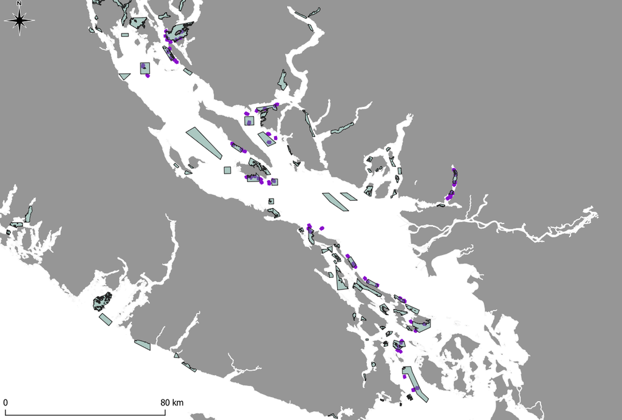

RCAs and 2018 Vector ROV transects from QGIS

Data were collected around 18 RCAS.

```
## [[1]]
##  [1] "Brethour,Domville,Forrest,Gooch Islands"
##  [2] "D'Arcy Island to Beaumont Shoal"
##  [3] "South Saturna"
##  [4] "Mayne Island North"
##  [5] "Galiano Island North"
##  [6] "Valdes Island East"
##  [7] "Indian Arm - Twin Islands"
##  [8] "Indian Arm - Crocker Island"
##  [9] "Northumberland Channel"
## [10] "Lasqueti South -Young Point"
## [11] "Lasqueti Island South"
## [12] "Davie Bay"
## [13] "Malaspina Strait"
## [14] "Sinclair Bank"
## [15] "Desolation Sound"
## [16] "Copeland Islands"
## [17] "Mitlenatch Island"
## [18] "Hardy Island"
```

## BASIC DATA SUMMARIES

Total fish seen in and out of RCAs

```
## # A tibble: 2 x 2
##   RCA   total
##   <chr> <dbl>
## 1 IN      695
## 2 OUT    1479
```

Types of primary substrate and how many times they were observed

```
## # A tibble: 8 x 2
##   Substrate total
##   <chr>     <dbl>
## 1 A             4
## 2 B           136
## 3 C            61
## 4 H            20
## 5 M           866
## 6 P             9
## 7 R          1076
## 8 S             2
```

Number of fish seen by transect

```
## # A tibble: 83 x 2
##    SurveyID  total
##    <chr>     <dbl>
##  1 Explore1      3
##  2 Explore2      8
##  3 Explore3      6
##  4 Explore4    168
##  5 Explore5     84
##  6 H010-CA-V    15
##  7 H011-CA-V     4
##  8 H015-CA-V    13
##  9 H016-CA-V    16
## 10 H017-CA-V    25
## # ... with 73 more rows
```

Number of fish of each species across all transects

```
## # A tibble: 19 x 2
##    Species                  total
##    <chr>                    <dbl>
##  1 Quillback rockfish         822
##  2 Greenstriped rockfish      520
##  3 Puget Sound rockfish       230
##  4 Yelloweye rockfish         202
##  5 Lingcod                    161
##  6 Rockfish uniden.            73
##  7 Yellowtail rockfish         46
##  8 Canary rockfish             25
##  9 Kelp greenling              24
## 10 Unidentified fish           24
## 11 Copper rockfish             19
## 12 Tiger rockfish               9
## 13 Redstripe rockfish           7
## 14 Red Irish Lord               5
## 15 Great sculpin                2
## 16 Sculpin uniden.              2
## 17 Hexagrammid uniden.          1
## 18 Pacific staghorn sculpin     1
## 19 Red brotula                  1
```

## FISH ABUNDANCES

Some basic plots pooling over all transects. You can see that certain species were seen in clusters and others were usually solitary.

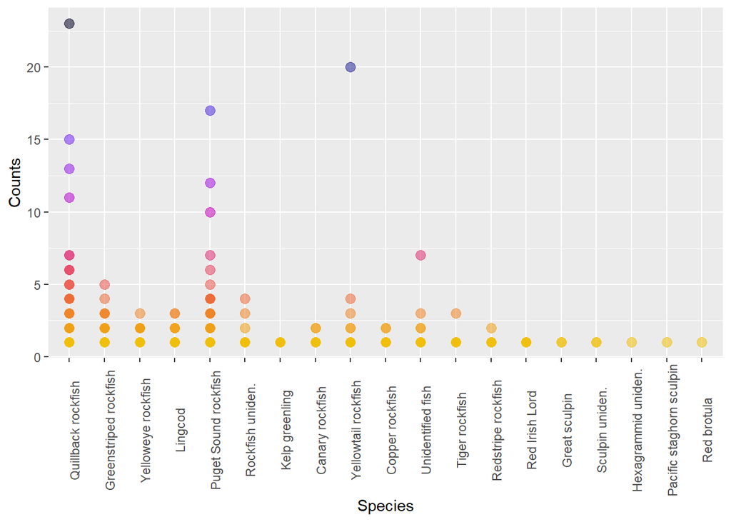

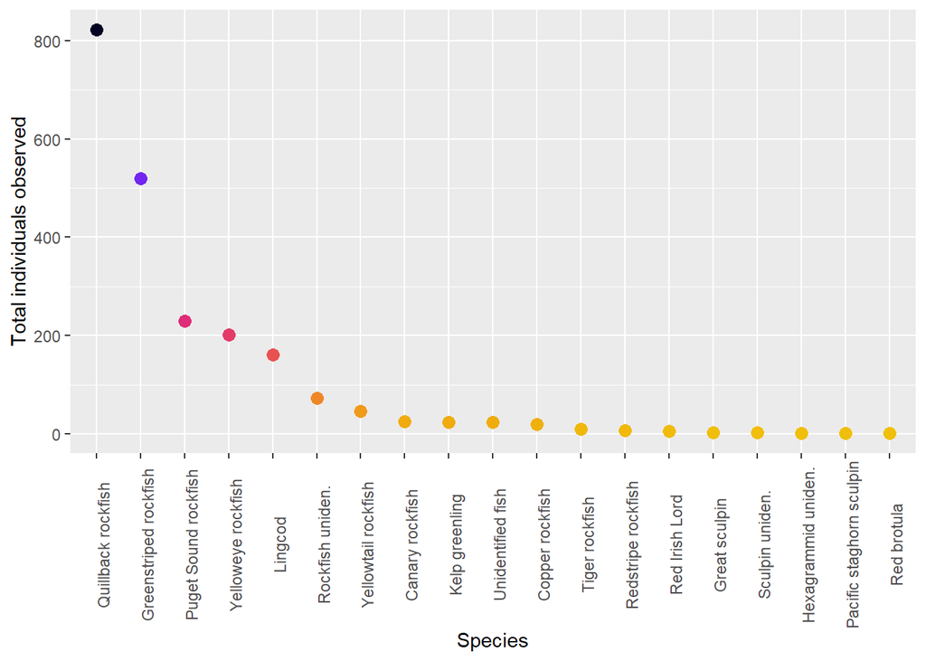

## TRANSECT AREAS

These were calculated so that we can determine fish densities per transect. I wanted to do this by creating segments along each transect using width measurements every 30 seconds however there were a lot of missing values so I have done this the simple way of taking the total distance of each transect and multiplying it by the average width pf the lasers (width was measured every 30 seconds).

```
## # A tibble: 86 x 2
##    Survey.abbrv transect.area
##    <chr>                <dbl>
##  1 Exp1_P1               681.
##  2 Exp2_P1               838.
##  3 Exp3_P1              1146.
##  4 Exp4_P1              1239.
##  5 Exp5_P1              1681.
##  6 H010_P1              1372.
##  7 H011_P1              1472.
##  8 H015_P1               263.
##  9 H015_P2               938.
## 10 H016_P1              1253.
## 11 H017_P1              1323.
## 12 H018_P1              1324.
```

[output cut: 74 more lines]

## DENSITIES

### ALL SPECIES DENSITIES

These were determined by combining transect areas with fish abundances and so we have one density per species per transect.

Fish densities by RCA

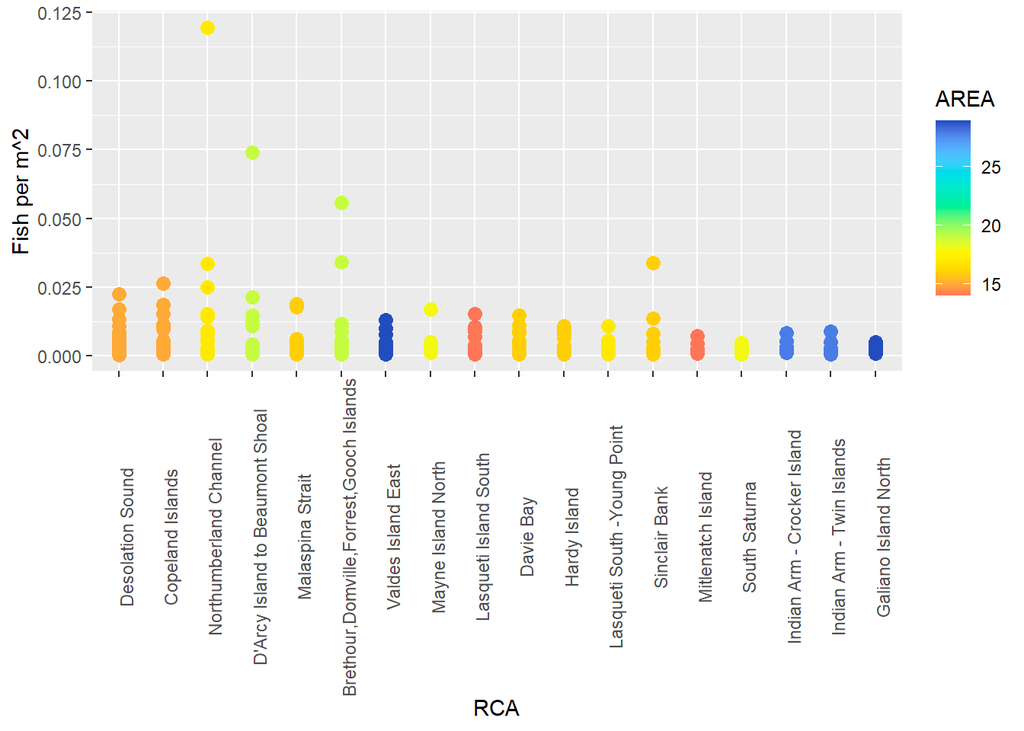

Densities by RCA region coloured by species

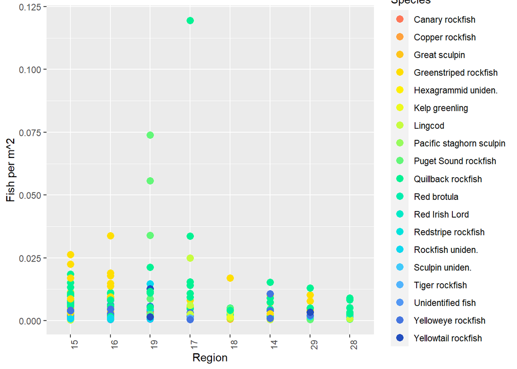

Fish densities by region coloured by RCA

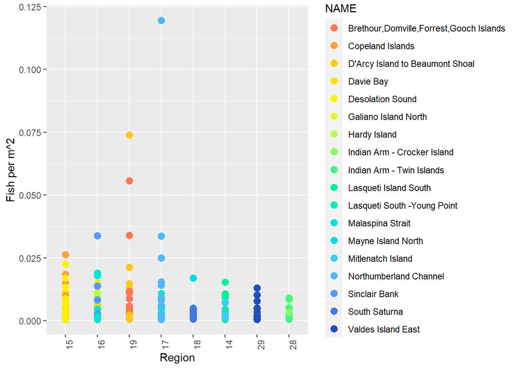

A series of denisity plots coloured by different variables

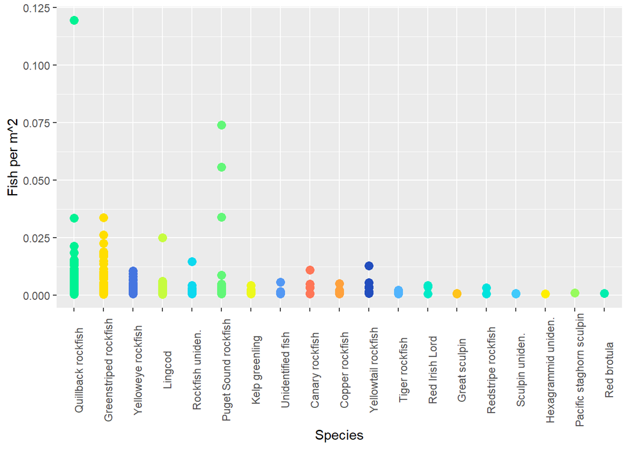

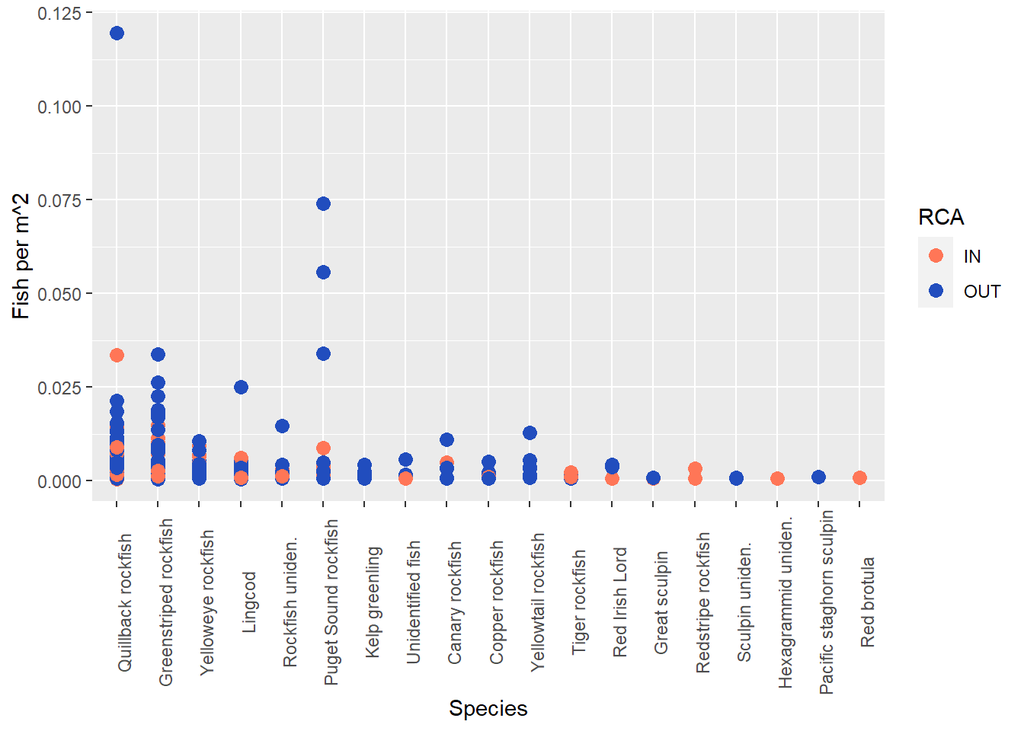

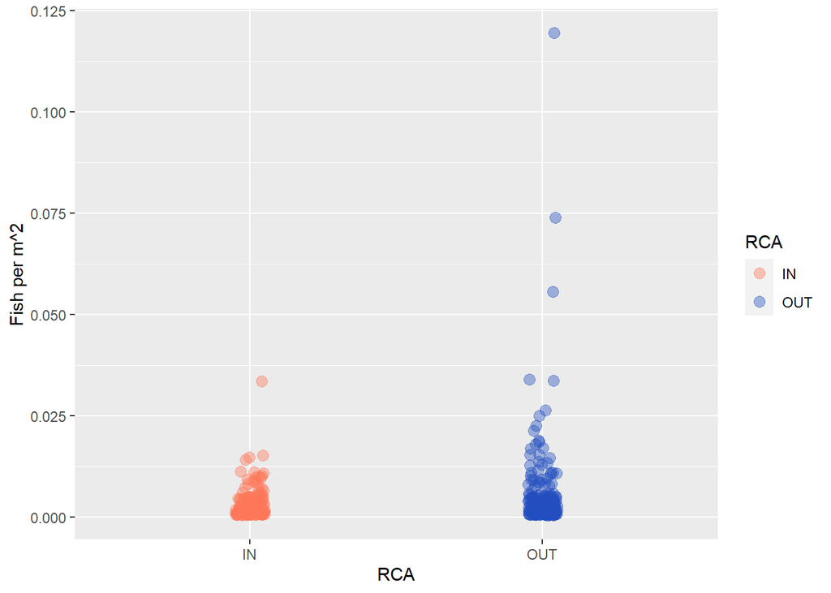

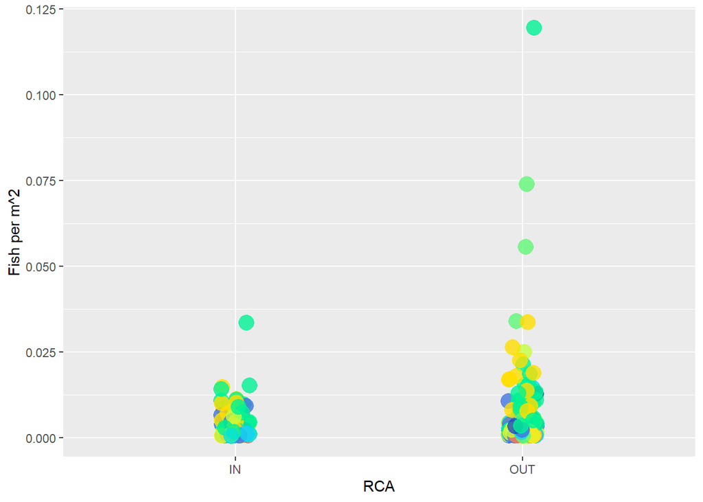

### Rockfish Densities

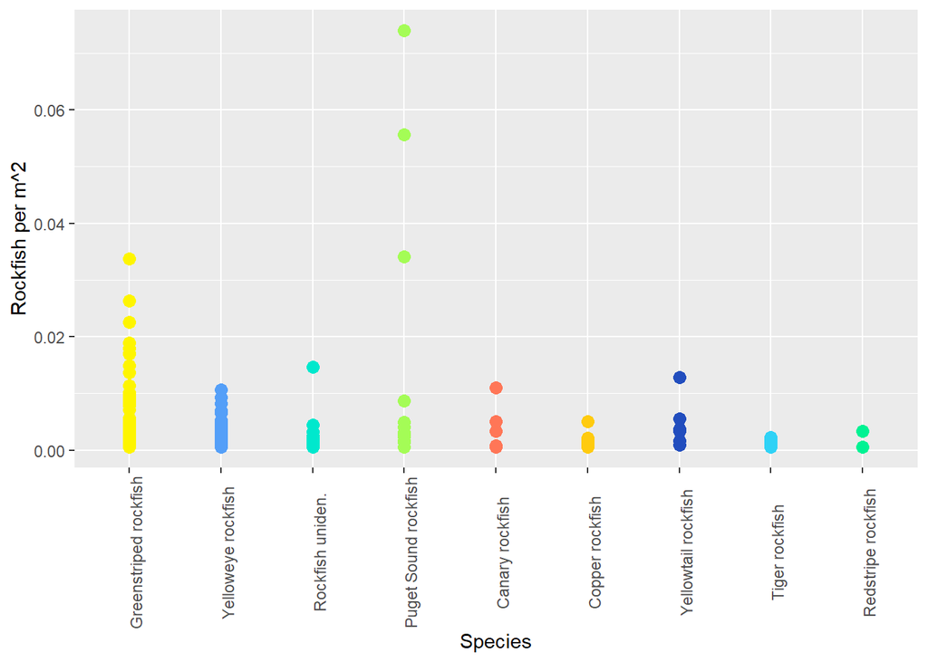

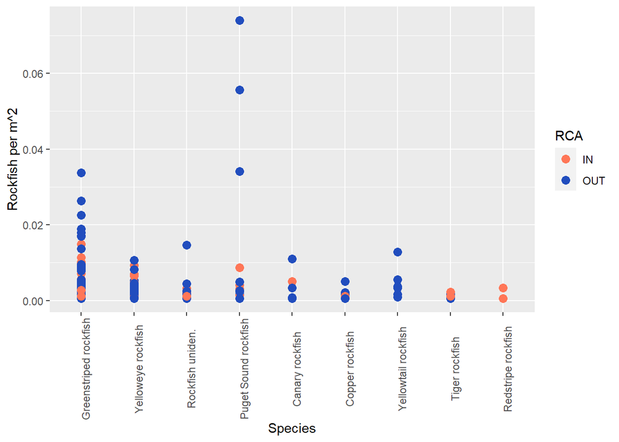

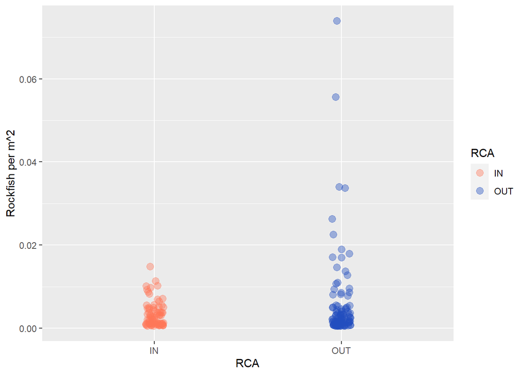

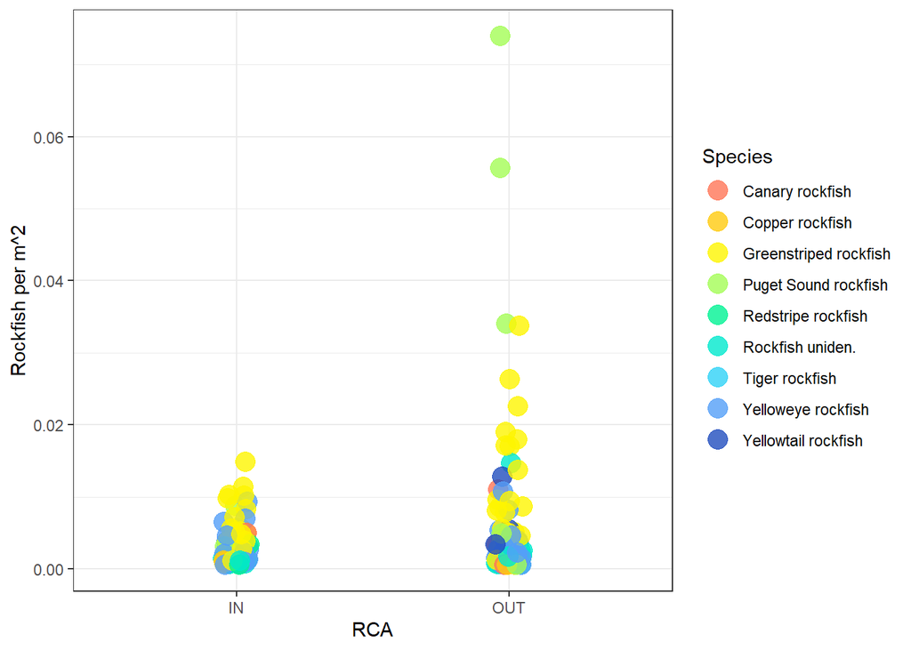

### Quillback Densities

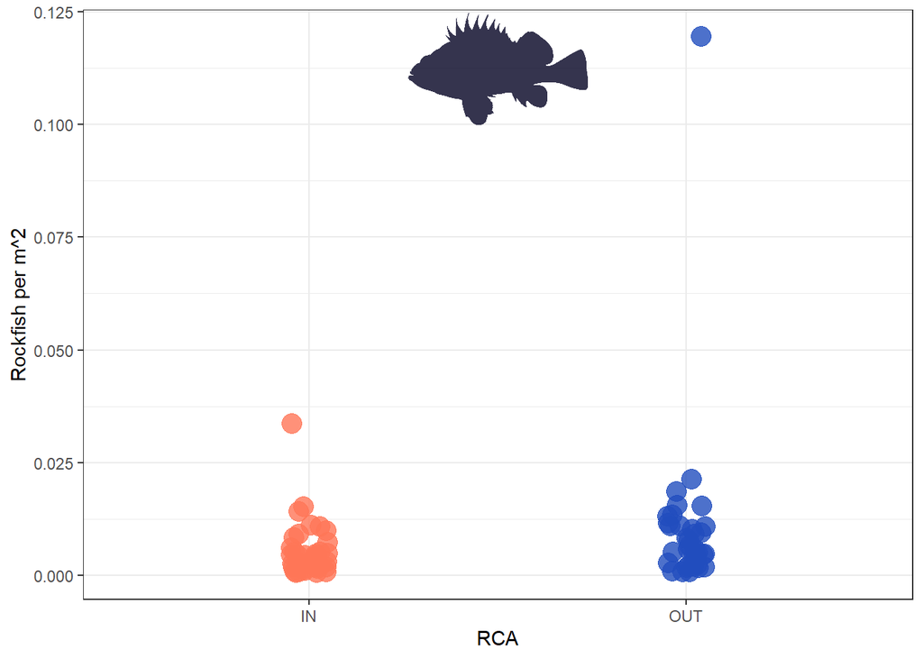

## SUBSTRATE

DFO measured habitat continuously in their transects (so every time the habitat changed they recorded that change you so you could calculate the area of each habitat type). The WDFW records the habitat every 30 seconds instead so you really only get these point measures (because habitat could have changed several times in each segment). So I am going to calucate the % habitat of each transect simply by treating each measure as a sample point (e.g. if there were 40, 30 second segments that is 40 habitat measures) and then dividing each type by the total (e.g. 3 records of rock would be 3/40 as the % of rock on that transect) Does this make sense?

Count of substrate 1 per surveyID divided by the total number of records of substrate in that SurveyID but need to do this with the width data csv not the all.data data frame (because that only has the habitats associated with fish)

```
## # A tibble: 9 x 3
##   sub.types               mean.percent sd.percent
##   <chr>                          <dbl>      <dbl>
## 1 mixed coarse_bare             0.117     0.152
## 2 mixed coarse_emergent         0.0260    0.00974
## 3 mixed coarse_encrusting       0.0333   NA
## 4 mixed fine_bare               0.625     0.290
## 5 mixed fine_emergent           0.208     0.181
## 6 mixed fine_encrusting         0.0174    0.00107
## 7 rock_bare                     0.284     0.202
## 8 rock_emergent                 0.183     0.263
## 9 rock_encrusting               0.0948    0.133
```

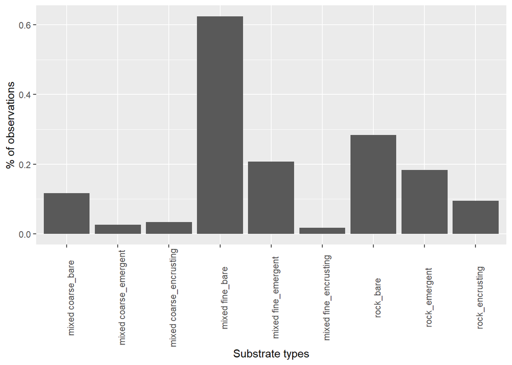

```r
# plot of the 9 substrate categories (bar plot of mean % and SD)
all.types
```

```r
all.types.by.RCA
```

```
## # A tibble: 16 x 4
## # Groups:   RCA [2]
##    RCA   sub.types               mean.percent sd.percent
##    <chr> <chr>                          <dbl>      <dbl>
##  1 IN    mixed coarse_bare             0.0702   0.107
##  2 IN    mixed coarse_emergent         0.0285   0.0102
##  3 IN    mixed fine_bare               0.644    0.255
##  4 IN    mixed fine_emergent           0.209    0.159
##  5 IN    mixed fine_encrusting         0.0174   0.00107
##  6 IN    rock_bare                     0.305    0.215
##  7 IN    rock_emergent                 0.0879   0.0771
##  8 IN    rock_encrusting               0.0191   0.000913
##  9 OUT   mixed coarse_bare             0.187    0.185
## 10 OUT   mixed coarse_emergent         0.0185  NA
## 11 OUT   mixed coarse_encrusting       0.0333  NA
## 12 OUT   mixed fine_bare               0.605    0.324
## 13 OUT   mixed fine_emergent           0.206    0.210
## 14 OUT   rock_bare                     0.265    0.191
## 15 OUT   rock_emergent                 0.251    0.326
## 16 OUT   rock_encrusting               0.133    0.152
```

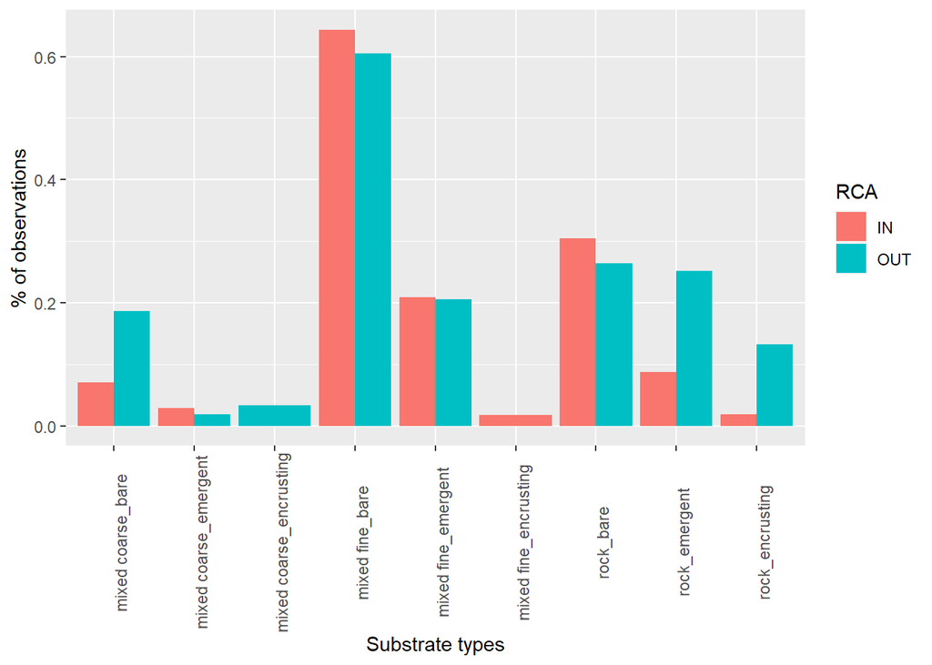

### FISH OCCURANCES IN RELATION TO SUBSTRATE

```
## # A tibble: 219 x 5
## # Groups:   Survey.abbrv, RCA [86]
##    Survey.abbrv RCA   sub.types           all.fish     n
##    <chr>        <chr> <chr>                  <dbl> <dbl>
##  1 Exp1_P1      OUT   rock_bare                  3     3
##  2 Exp2_P1      IN    rock_bare                  8     8
##  3 Exp3_P1      IN    rock_bare                  6     6
##  4 Exp4_P1      OUT   mixed coarse_bare         26   168
##  5 Exp4_P1      OUT   mixed fine_bare            4   168
##  6 Exp4_P1      OUT   rock_bare                136   168
##  7 Exp4_P1      OUT   rock_encrusting            2   168
##  8 Exp5_P1      OUT   mixed coarse_bare          6    84
##  9 Exp5_P1      OUT   mixed fine_bare           11    84
## 10 Exp5_P1      OUT   mixed fine_emergent       12    84
## # ... with 209 more rows
```

### PLOTS OF FISH HABITAT USE

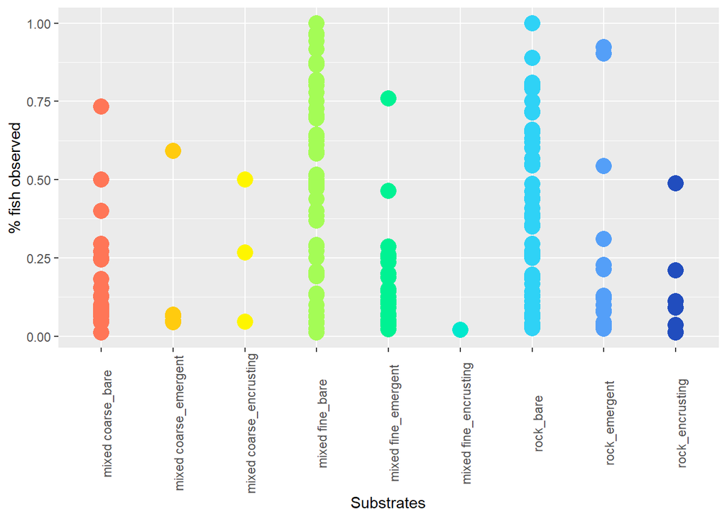

```r
# plot fish % occurrences across all transects

ggplot(fish.sub.types) + geom_point(aes(sub.types,percent,  colour = sub.types), size = 5, show.legend = F) +
    scale_color_fish_d(option = "Cirrhilabrus_solorensis", direction = -1) +
  theme(axis.text.x = element_text(angle = 90)) +
  xlab("Substrates") +
  ylab("% fish observed")
```

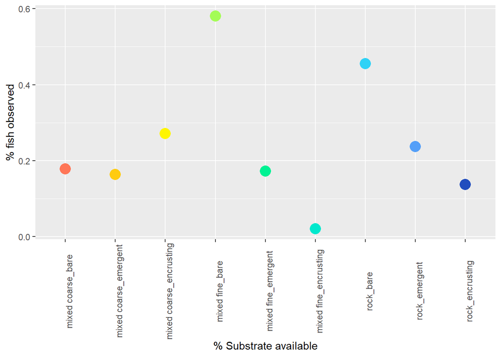

```r
# plot mean % fish occurances

ggplot(fish.sub.use) + geom_point(aes( sub.types,fish.occurance, colour = sub.types), size = 5, show.legend = F) +
    scale_color_fish_d(option = "Cirrhilabrus_solorensis", direction = -1) +
  theme(axis.text.x = element_text(angle = 90)) +
  xlab("% Substrate available") +
  ylab("% fish observed")
```

```r
# make into bar plot, first need to convert to long format
fish.sub.compare <- fish.sub.use %>% select(sub.types, fish.occurance, substrate.occurance)
fish.sub.compare <- gather(fish.sub.use, type, total,fish.occurance, substrate.occurance) #Create long format
fish.sub.compare
```

```
## # A tibble: 18 x 5
##    sub.types               fish.sd.percent sd.percent type                 total
##    <chr>                             <dbl>      <dbl> <chr>                <dbl>
##  1 mixed coarse_bare                 0.162    0.152   fish.occurance      0.179
##  2 mixed coarse_emergent             0.240    0.00974 fish.occurance      0.164
##  3 mixed coarse_encrusting           0.227   NA       fish.occurance      0.271
##  4 mixed fine_bare                   0.346    0.290   fish.occurance      0.581
##  5 mixed fine_emergent               0.163    0.181   fish.occurance      0.172
##  6 mixed fine_encrusting            NA        0.00107 fish.occurance      0.0204
##  7 rock_bare                         0.314    0.202   fish.occurance      0.456
##  8 rock_emergent                     0.285    0.263   fish.occurance      0.236
##  9 rock_encrusting                   0.170    0.133   fish.occurance      0.137
## 10 mixed coarse_bare                 0.162    0.152   substrate.occurance 0.117
## 11 mixed coarse_emergent             0.240    0.00974 substrate.occurance 0.0260
## 12 mixed coarse_encrusting           0.227   NA       substrate.occurance 0.0333
## 13 mixed fine_bare                   0.346    0.290   substrate.occurance 0.625
## 14 mixed fine_emergent               0.163    0.181   substrate.occurance 0.208
## 15 mixed fine_encrusting            NA        0.00107 substrate.occurance 0.0174
## 16 rock_bare                         0.314    0.202   substrate.occurance 0.284
## 17 rock_emergent                     0.285    0.263   substrate.occurance 0.183
## 18 rock_encrusting                   0.170    0.133   substrate.occurance 0.0948
```

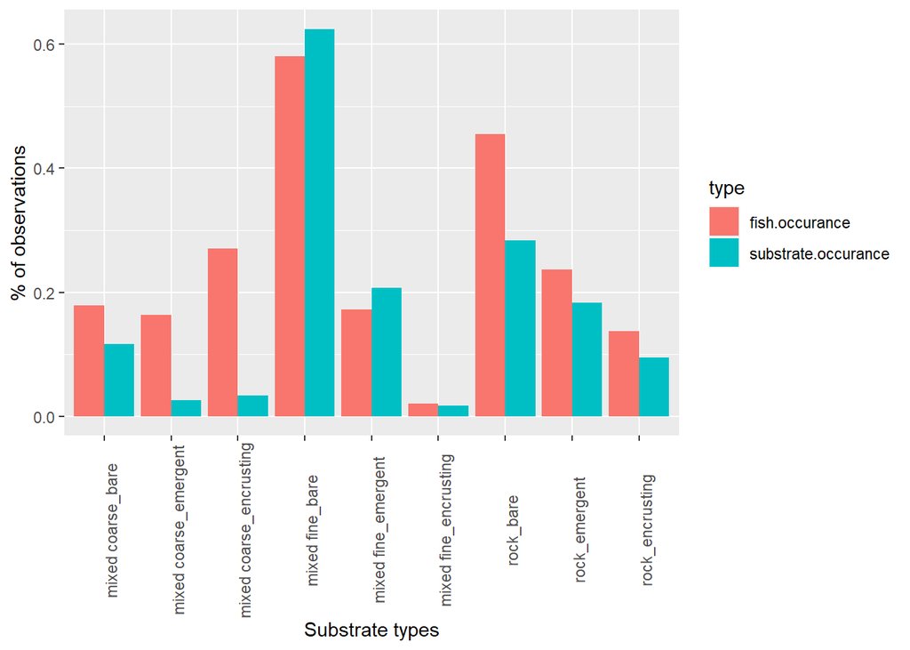

```r
# bar plot of mean % fish occurances and mean % sub occurances over all transects
ggplot(fish.sub.compare) + geom_col(aes(x = sub.types, y = total, fill = type), position = "dodge") +
    scale_color_fish_d(option = "Cirrhilabrus_solorensis", direction = -1) +
  theme(axis.text.x = element_text(angle = 90)) +
  xlab("Substrate types") +
  ylab("% of observations")
```

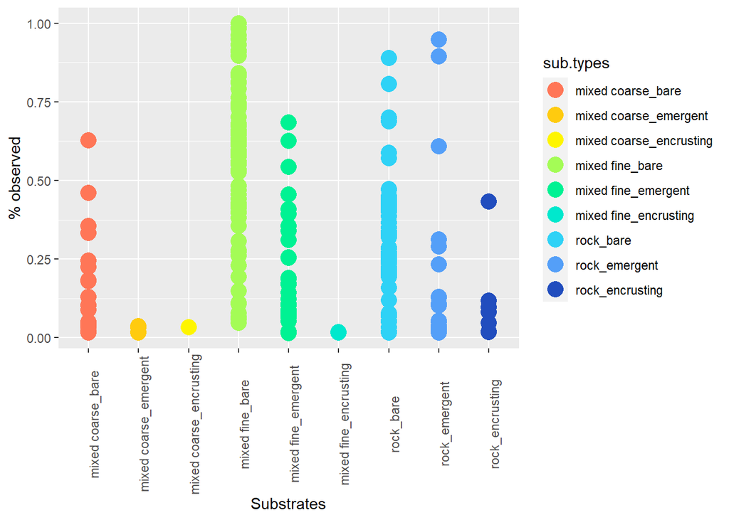

```r
# plot substrate %s across all transects

ggplot(percent.sub) + geom_point(aes(sub.types,percent,  colour = sub.types), size = 5, show.legend = T) +
    scale_color_fish_d(option = "Cirrhilabrus_solorensis", direction = -1) +
  theme(axis.text.x = element_text(angle = 90)) +
  xlab("Substrates") +
  ylab("% observed")
```

[figure not shown]

```r
# plot mean fish sub use against mean sub availability (don't worry about error for now)

ggplot(fish.sub.use) + geom_point(aes(fish.occurance, substrate.occurance, colour = sub.types), size = 5, show.legend = T) +
    scale_color_fish_d(option = "Cirrhilabrus_solorensis", direction = -1) +
  theme(axis.text.x = element_text(angle = 90)) +
  xlab("% Substrate available") +
  ylab("% fish observed")
```